# Decision Tree Classifier (Hotel Cancelation Rate)

#### Meal Type

Did the type of meal affect the cancellation rate?

```r
meal_cancellation_rate <- hotel_bookings %>%
  group_by(meal) %>%
  summarise(cancellation_rate = mean(is_canceled), .groups = 'drop') %>%
  mutate(cancellation_rate_percent = scales::percent(cancellation_rate))


print(meal_cancellation_rate)
```

```
## # A tibble: 5 × 3
##   meal      cancellation_rate cancellation_rate_percent
##   <chr>                 <dbl> <chr>
## 1 BB                    0.374 37.38%
## 2 FB                    0.599 59.90%
## 3 HB                    0.345 34.46%
## 4 SC                    0.372 37.24%
## 5 Undefined             0.245 24.47%
```

Based on my analysis of the data, I found that bookings with the ‘FB’ (Full Board) option had the highest cancellation rate. However, it’s important to consider that this might just be a coincidence, as all other meal options showed slightly similar cancellation rates, with the exception of ‘Undefined’. The similarities in rates across most meal options suggest that the high rate for ‘FB’ might not be exclusively linked to the meal choice itself.

#### Market Segment

What can be inferred about the cancellation rates across different market segments? particularly noting any segments with notably high or low rates.

```r
# Market Segment Analysis
market_segment_analysis <- hotel_bookings %>%
  group_by(market_segment) %>%
  summarise(total_bookings = n(),
            total_cancellations = sum(is_canceled),
            cancellation_rate = mean(is_canceled)) %>%
  arrange(desc(total_bookings))

print(market_segment_analysis)
```

```
## # A tibble: 8 × 4
##   market_segment total_bookings total_cancellations cancellation_rate
##   <chr>                   <int>               <int>             <dbl>
## 1 Online TA               56477               20739             0.367
## 2 Offline TA/TO           24219                8311             0.343
## 3 Groups                  19811               12097             0.611
## 4 Direct                  12606                1934             0.153
## 5 Corporate                5295                 992             0.187
## 6 Complementary             743                  97             0.131
## 7 Aviation                  237                  52             0.219
## 8 Undefined                   2                   2             1
```

The analysis of cancellation rates across different market segments in the hotel booking data reveals notable differences. The 'Groups' segment exhibits the highest cancellation rate at 61.1%, suggesting that group bookings may be more volatile and prone to changes, possibly due to the logistical complexities associated with coordinating larger parties. This was shown with the guest composition as well, with the larger adult groups cancelling at a 100% rate. In contrast, the 'Online TA' (Travel Agency) segment, while having a substantial volume of total bookings (56,477), shows a moderately high cancellation rate of 36.7%. This is slightly higher than the 'Offline TA/TO' (Travel Agent/Tour Operator) segment, which has a cancellation rate of 34.3%, indicating that online bookings might be subject to more frequent cancellations compared to offline methods.

#### Distribution Channel Analysis

What can be inferred about the impact of different distribution channels on hotel booking cancellations?

```r
distribution_channel_analysis <- hotel_bookings %>%
  group_by(distribution_channel) %>%
  summarise(total_bookings = n(),
            total_cancellations = sum(is_canceled),
            cancellation_rate = mean(is_canceled)) %>%
  arrange(desc(total_bookings))

print(distribution_channel_analysis)
```

```
## # A tibble: 5 × 4
##   distribution_channel total_bookings total_cancellations cancellation_rate
##   <chr>                         <int>               <int>             <dbl>
## 1 TA/TO                         97870               40152             0.410
## 2 Direct                        14645                2557             0.175
## 3 Corporate                      6677                1474             0.221
## 4 GDS                             193                  37             0.192
## 5 Undefined                         5                   4             0.8
```

In the hotel booking data, the 'TA/TO' (Travel Agent/Tour Operator) distribution channel accounts for the highest number of total bookings (97,870) but also has a notably high cancellation rate of 41.0%. Conversely, 'Direct' bookings, though fewer in total (14,645), show a significantly lower cancellation rate of 17.5%. The 'Corporate' channel, with a total of 6,677 bookings, has a cancellation rate of 22.1%, while the 'GDS' (Global Distribution System) channel, though representing a small fraction of bookings (193), has a relatively low cancellation rate of 19.2%. The 'Undefined' channel, with minimal bookings (5), shows an exceptionally high cancellation rate of 80%, suggesting it might be an outlier or an area requiring further investigation.

#### Guest Booking Preferences

How do guests' room type preferences correlate with cancellation rates?

```r
guest_booking_preferences <- hotel_bookings %>%
  group_by( reserved_room_type) %>%
  summarise(
    total_bookings = n(),
    cancellation_rate = mean(is_canceled),
    .groups = 'drop'
  ) %>%
  arrange(desc(cancellation_rate))

# Viewing the table
print(guest_booking_preferences)
```

```
## # A tibble: 10 × 3
##    reserved_room_type total_bookings cancellation_rate
##    <chr>                       <int>             <dbl>
##  1 P                              12             1
##  2 H                             601             0.408
##  3 A                           85994             0.391
##  4 G                            2094             0.364
##  5 L                               6             0.333
##  6 C                             932             0.330
##  7 B                            1118             0.329
##  8 D                           19201             0.318
##  9 F                            2897             0.304
## 10 E                            6535             0.293
```

Guest booking preferences shows a diverse range of cancellation rates across different reserved room types. Room type 'P', despite a small sample size (12 bookings), exhibits a 100% cancellation rate. More commonly reserved room types such as 'A' (85,994 bookings) and 'D' (19,201 bookings) have cancellation rates of 39.1% and 31.8%, respectively. Other room types like 'G' (2,094 bookings) and 'C' (932 bookings) also display substantial cancellation rates at 36.4% and 33.0%. Notably, room types 'F' and 'E', with more moderate booking volumes (2,897 and 6,535 bookings), show relatively lower cancellation rates of 30.4% and 29.3%, indicating a potential pattern in guest preferences and commitment stability.

#### Yearly, Monthly, and Weekly trends

Did the yearly, monthly, or weekly trends have a huge impact on the cancellation rate?

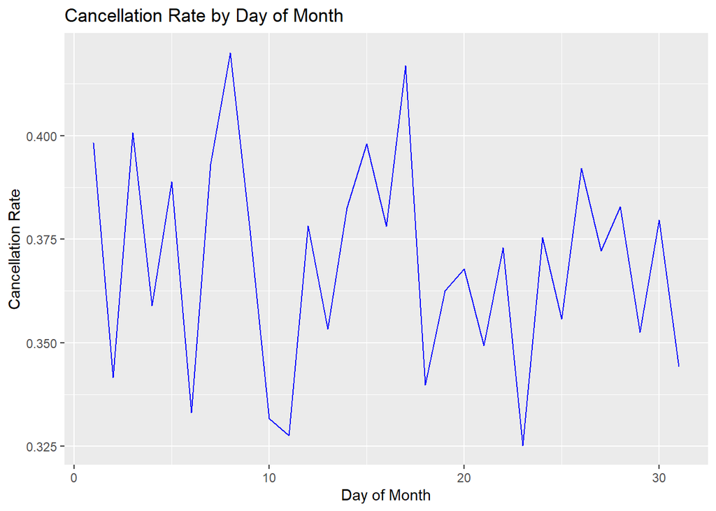

```r
# Cancellation rate by day of month
day_cancellation_rate <- hotel_bookings %>%
  group_by(arrival_date_day_of_month) %>%
  summarise(cancellation_rate = mean(is_canceled))

# Plot
ggplot(day_cancellation_rate, aes(x = arrival_date_day_of_month, y = cancellation_rate)) +
  geom_line(group = 1, color = "blue") +
  labs(title = "Cancellation Rate by Day of Month", x = "Day of Month", y = "Cancellation Rate")
```

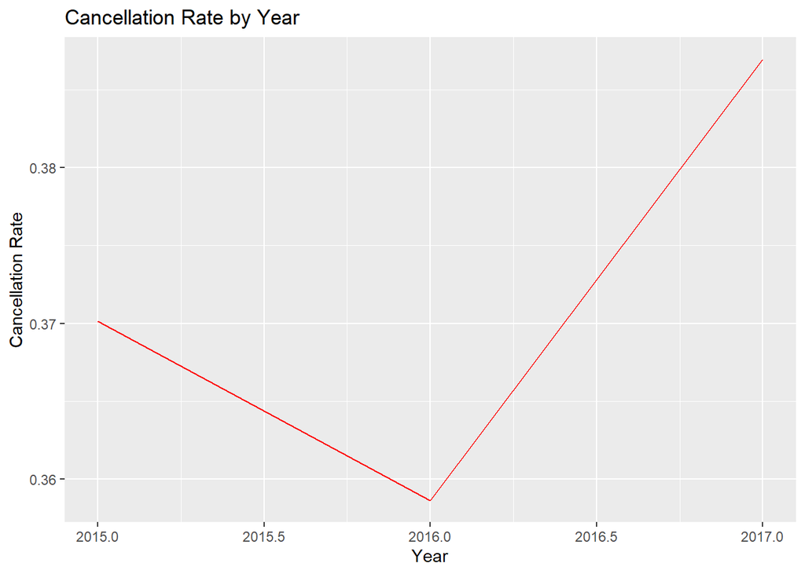

```r
# Cancellation rate by year
year_cancellation_rate <- hotel_bookings %>%
  group_by(arrival_date_year) %>%
  summarise(cancellation_rate = mean(is_canceled))

# Plot
ggplot(year_cancellation_rate, aes(x = arrival_date_year, y = cancellation_rate)) +
  geom_line(group = 1, color = "red") +
  labs(title = "Cancellation Rate by Year", x = "Year", y = "Cancellation Rate")
```

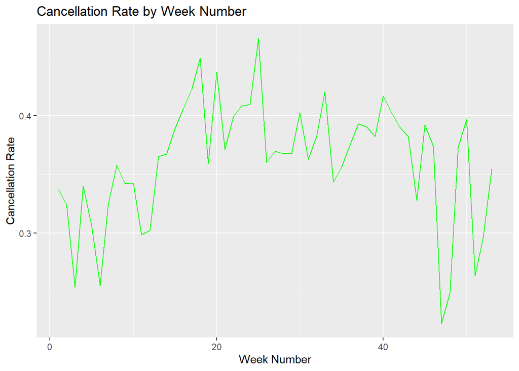

```r
# Cancellation rate by week number
week_cancellation_rate <- hotel_bookings %>%
  group_by(arrival_date_week_number) %>%
  summarise(cancellation_rate = mean(is_canceled))

# Plot
ggplot(week_cancellation_rate, aes(x = arrival_date_week_number, y = cancellation_rate)) +
  geom_line(group = 1, color = "green") +
  labs(title = "Cancellation Rate by Week Number", x = "Week Number", y = "Cancellation Rate")
```

#### Canceled vs Non-Canceled

```r
# retrieving number of both, non canceled and canceled customers
  class_frequency <- table(hotel_bookings$is_canceled)
canceled_count <- class_frequency[["1"]]
not_canceled_count <- class_frequency[["0"]]

cat("Number of guests who canceled reservation:", canceled_count, "\n",
    "Number of guests who did not cancel the reservation:", not_canceled_count)
```

```
## Number of guests who canceled reservation: 44224
##  Number of guests who did not cancel the reservation: 75166
```

**Canceled and Non-Canceled Reservations Analysis:** The data revealed that out of the total guests, 44,224 had canceled their reservations, while 75,166 guests did not cancel. This prompts the question: What might be influencing guests' decisions to cancel or keep their reservations? The analysis suggests that factors such as seasonality, booking lead time, and special requests could play significant roles in influencing cancellation behavior. Understanding these factors can provide valuable insights into guest preferences and booking patterns at the hotels.

#### Customer Type

**Most Common Customer Type:** Among the various customer types, 'Transient' emerged as the most common, with 89,613 reservations. This raises the question: Why is the 'Transient' category more prevalent than others? The data suggests that factors such as flexibility in booking, shorter duration of stays, and possibly competitive pricing may contribute to the higher prevalence of transient customers. Understanding these aspects can be crucial for developing targeted marketing strategies and optimizing services to cater to this predominant customer segment.

```r
# returning the customer type with the most number of reservations
customer_type_frequency <- table(hotel_bookings$customer_type)
max_index <- which.max(customer_type_frequency)
most_common_customer_type <- names(customer_type_frequency)[max_index]
number_of_reservations <- customer_type_frequency[max_index]

output_string <- paste("Customer type with the most reservations is", most_common_customer_type, ", with",
                       number_of_reservations, "reservations")
print(output_string)
```

```
## [1] "Customer type with the most reservations is Transient , with 89613 reservations"
```

#### Parking Spaces

**Maximum Parking Space Requirements:** A unique finding was that only 2 customers required the maximum number of parking spaces, which was 8. This indicates that parking space requirements are generally low among the hotel guests.

```r
# returning both, max number of parking spaces and customers with those spaces.
parking_space_frequency <- table(hotel_bookings$required_car_parking_spaces)
required_parking_spaces <- as.numeric(names(parking_space_frequency))
max_number_of_required_spaces <- max(required_parking_spaces)

max_required_parking_spaces_index <- which.max(required_parking_spaces)
number_of_customers_with_max_spaces <-parking_space_frequency[max_required_parking_spaces_index]


output_string <- paste(number_of_customers_with_max_spaces, " customers required the most number of parking spaces (", max_number_of_required_spaces, ").", sep = "")

print(output_string)
```

```
## [1] "2 customers required the most number of parking spaces (8)."
```

```r
matching_rows <- hotel_bookings[hotel_bookings$required_car_parking_spaces == max_number_of_required_spaces, ]
print(matching_rows)
```

```
##              hotel is_canceled lead_time arrival_date_year arrival_date_month
## 29046 Resort Hotel           0        26              2017              March
## 29047 Resort Hotel           0       138              2017              March
##       arrival_date_week_number arrival_date_day_of_month
## 29046                       11                        14
## 29047                       12                        19
##       stays_in_weekend_nights stays_in_week_nights adults children babies meal
## 29046                       0                    5      2        0      0   HB
## 29047                       2                    2      2        0      0   HB
##       country market_segment distribution_channel is_repeated_guest
## 29046     AUT         Direct            Corporate                 1
## 29047     AUT         Direct            Corporate                 1
##       previous_cancellations previous_bookings_not_canceled reserved_room_type
## 29046                      0                              2                  E
## 29047                      0                              2                  E
##       assigned_room_type booking_changes deposit_type agent company
## 29046                  I               1   No Deposit  NULL    NULL
## 29047                  F               1   No Deposit  NULL    NULL
##       days_in_waiting_list   customer_type adr required_car_parking_spaces
## 29046                    0 Transient-Party  40                           8
## 29047                  122 Transient-Party  80                           8
##       total_of_special_requests reservation_status reservation_status_date
## 29046                         1          Check-Out              2017-03-19
## 29047                         0          Check-Out              2017-03-23
```

**Minimum Parking Space Requirements:** In stark contrast to the maximum requirements, a significant majority of 111,974 customers did not require any parking space, highlighting the minimal parking needs of most hotel guests.

```r
parking_space_frequency <- table(hotel_bookings$required_car_parking_spaces)
required_parking_spaces <- as.numeric(names(parking_space_frequency))
min_number_of_required_spaces <- min(required_parking_spaces)

min_required_parking_spaces_index <- which.min(required_parking_spaces)
number_of_customers_with_min_spaces <-parking_space_frequency[min_required_parking_spaces_index]


output_string <- paste(number_of_customers_with_min_spaces, " customers required the least number of parking spaces (", min_number_of_required_spaces, ").", sep = "")

print(output_string)
```

```
## [1] "111974 customers required the least number of parking spaces (0)."
```

```r
#matching_rows <- hotel_bookings[hotel_bookings$required_car_parking_spaces == min_number_of_required_spaces, ]
#print(matching_rows)
```

#### Room Preferences

**Room Preference Fulfillment:** Analysis showed that 87.51% of guests who had a room preference during reservation were assigned their preferred room during check-in. This high percentage suggests effective room allocation practices by the hotels.

```r
num_preferred <- sum(!is.na(hotel_bookings$reserved_room_type))
num_assigned_pref <- sum(hotel_bookings$assigned_room_type == hotel_bookings$reserved_room_type)

# calculate the percentage of people who were assigned their preferred room type
percentage <- 100 * num_assigned_pref / num_preferred

cat(sprintf("%.2f%% of the people who expressed a room preference during reservation got the room during check-in.", percentage))
```

```
## 87.51% of the people who expressed a room preference during reservation got the room during check-in.
```

### Plots Showcasing Top 10 Countries for Resort/City Hotels

**Top 10 Countries of Origin for City and Resort Hotels:** The data visualizations provided insights into the top 10 countries of origin for guests at both City and Resort Hotels. For City Hotels, the highest number of guests came from a diverse range of countries, with the most visitors being from Portugal. The analysis for Resort Hotels also showed a similar trend with a variety of countries making up the top 10, emphasizing the international appeal of these hotels.

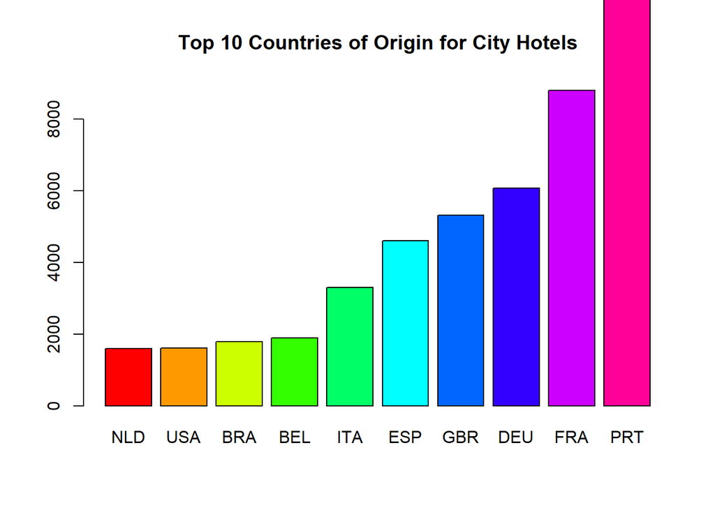

```r
# create separate data frames for city and resort hotels
# create a subset where hotel attribute equals type of hotel
city_hotels <- subset(hotel_bookings, hotel == "City Hotel")
resort_hotels <- subset(hotel_bookings, hotel == "Resort Hotel")

top_10_city_hotel_countries <- head(sort(table(city_hotels$country), decreasing = TRUE), 10)

# noticed a NULL value here (anamoly)
top_11_resort_hotel_countries <- head(sort(table(resort_hotels$country), decreasing = TRUE), 11)

# removing the NULL value from the 11 resort hotel countries to make it 10
if("NULL" %in% names(top_11_resort_hotel_countries)){
  top_10_resort_hotel_countries <- top_11_resort_hotel_countries[names(top_11_resort_hotel_countries) != "NULL"]
}

barplot(sort(top_10_city_hotel_countries, increasing = TRUE),
        col = rainbow(10),
        ylim = c(0, 9000),
        main = "Top 10 Countries of Origin for City Hotels")
```

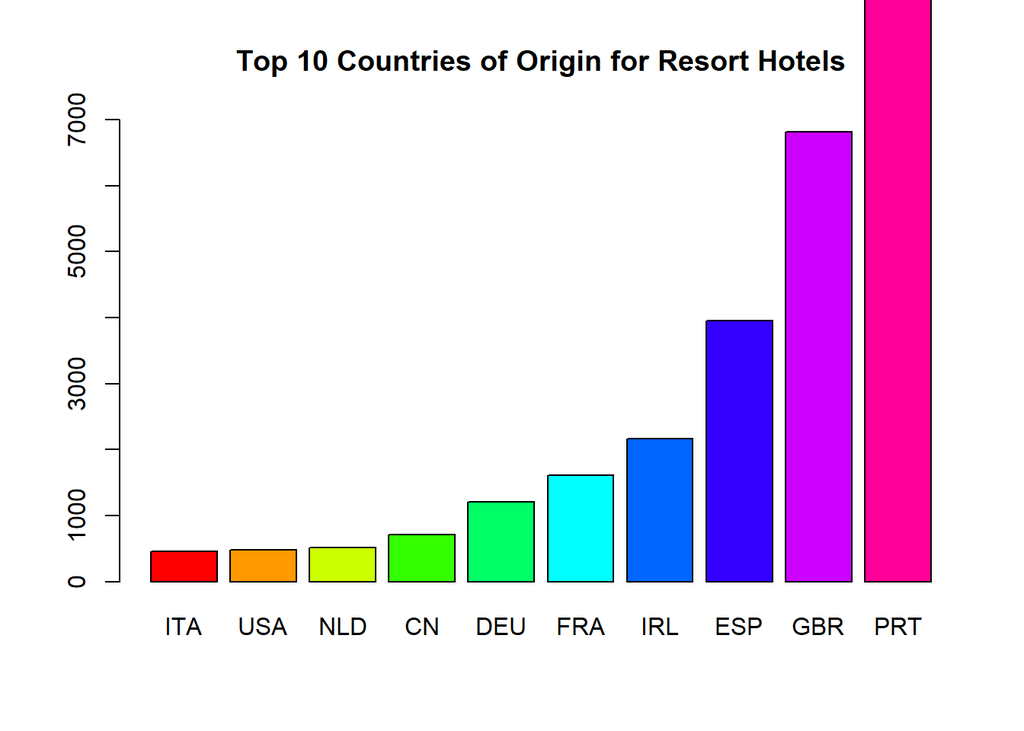

```r
barplot(sort(top_10_resort_hotel_countries, increasing = TRUE),
        col = rainbow(10),
        ylim = c(0, 7000),
        main = "Top 10 Countries of Origin for Resort Hotels")
```

```r
most_visitors <- names(which.max(table(hotel_bookings$country)))
cat("The country with the most visitors is", most_visitors, "\n")
```

```
## The country with the most visitors is PRT
```

### Data Cleaning

In this section, I focus on identifying missing values and irrelevant features within the dataset, both of which are essential for ensuring data quality. Detecting missing values is a crucial first step in data preparation, as it allows me to decide how to handle gaps, whether through imputation, removal, or other techniques. To streamline this process, I will create a function to calculate the percentage of missing values by column and display the results in a table. This will make it easier to pinpoint which columns contain missing data, allowing for more informed decisions during the cleaning process.

Additionally, I will address irrelevant or non-useful features in the dataset. These are variables that do not contribute meaningfully to the model’s predictive power and may introduce noise, increase computational complexity, or lead to overfitting. By identifying and removing such features, I can improve the efficiency, interpretability, and overall performance of the model, ensuring it generalizes better to new data. This will also provide me with the necessary information to determine if I need more data or features, and if some attributes need to be combined or split for better predective power.

```r
set.seed(1122)


# Load the required packages
library(xgboost)

# we can minimize the number of columns by combining the arrival month, day, and year into a single column
# I will first change the values of the arrival months to a numeric format so I can have the concatenation match the reservation date status
month_names <- c("January" = "01", "February" = "02", "March"="03", "April"="04", "May"="05", "June"="06",
                 "July"="07", "August"="08", "September"="09", "October"="10", "November"="11", "December"="12")

# just adding the leading zeros to generate a date format like the reservation status date
hotel_bookings$arrival_date_month <- month_names[hotel_bookings$arrival_date_month]
hotel_bookings$arrival_date_day_of_month <- sprintf("%02d", hotel_bookings$arrival_date_day_of_month)

# combining the values to form the single column
arrival_date <- paste(hotel_bookings$arrival_date_year, hotel_bookings$arrival_date_month, hotel_bookings$arrival_date_day_of_month, sep ="-")

hotel_bookings$arrival_date <- arrival_date
hotel_bookings$arrival_date_year <- NULL
hotel_bookings$arrival_date_month <- NULL
hotel_bookings$arrival_date_day_of_month <- NULL

# taking the strings and creating date objects out of them so we can perform comparison operations
hotel_bookings$reservation_status_date <- as.Date(hotel_bookings$reservation_status_date)
hotel_bookings$arrival_date <- as.Date(hotel_bookings$arrival_date)


check_values <- c("Undefined", "undefined", "NULL", "", NA)

# finding the sum of missing values for each column
missing_values <- sapply(hotel_bookings, function (x) sum(x %in% check_values))
missing_percentages <- sapply(hotel_bookings, function (x) mean(x %in% check_values) * 100)

# displaying the tables of missing values

knitr::kable(missing_values, align = "c")
```

#### Table showing missing all the missing values by column

|  | x |
| --- | --- |
| hotel | 0 |
| is_canceled | 0 |
| lead_time | 0 |
| arrival_date_week_number | 0 |
| stays_in_weekend_nights | 0 |
| stays_in_week_nights | 0 |
| adults | 0 |
| children | 4 |
| babies | 0 |
| meal | 1169 |
| country | 488 |
| market_segment | 2 |
| distribution_channel | 5 |
| is_repeated_guest | 0 |
| previous_cancellations | 0 |
| previous_bookings_not_canceled | 0 |
| reserved_room_type | 0 |
| assigned_room_type | 0 |
| booking_changes | 0 |
| deposit_type | 0 |
| agent | 16340 |
| company | 112593 |
| days_in_waiting_list | 0 |
| customer_type | 0 |
| adr | 0 |
| required_car_parking_spaces | 0 |
| total_of_special_requests | 0 |
| reservation_status | 0 |
| reservation_status_date | 0 |
| arrival_date | 0 |

```r
knitr::kable(missing_percentages, align = "c")
```

|  | x |
| --- | --- |
| hotel | 0% |
| is_canceled | 0% |
| lead_time | 0% |
| arrival_date_week_number | 0% |
| stays_in_weekend_nights | 0% |
| stays_in_week_nights | 0% |
| adults | 0% |
| children | 0.003% |
| babies | 0% |
| meal | 0.9% |
| country | 0.4% |
| market_segment | 0.001% |
| distribution_channel | 0.004% |
| is_repeated_guest | 0% |
| previous_cancellations | 0% |
| previous_bookings_not_canceled | 0% |
| reserved_room_type | 0% |
| assigned_room_type | 0% |
| booking_changes | 0% |
| deposit_type | 0% |
| agent | 13.6% |
| company | 94.3% |
| days_in_waiting_list | 0% |
| customer_type | 0% |
| adr | 0% |
| required_car_parking_spaces | 0% |
| total_of_special_requests | 0% |
| reservation_status | 0% |
| reservation_status_date | 0% |
| arrival_date | 0% |

#### Filling in all missing values by either mean, median, or mode.

Children Column

```r
# taking care of the missing children columns first
missing_children_indices <- which(is.na(hotel_bookings$children))


mean_of_children <- as.integer(floor(mean(hotel_bookings$children, na.rm = TRUE)))

# filling in the missing values with the mean value
hotel_bookings[missing_children_indices,]$children <- mean_of_children
```

Meal Column (Used mode for most popular meal. Average gave the same result.)

```r
# reference https://stackoverflow.com/questions/2547402/how-to-find-the-statistical-mode
find_mode <- function(x) {
  u <- unique(x)
  tab <- tabulate(match(x, u))
  u[tab == max(tab)]
}
#---------------------------------------------------------------------------------------

missing_meal_indices <- which(hotel_bookings$meal == "Undefined")
mode_of_meals <- find_mode(hotel_bookings$meal)
hotel_bookings[missing_meal_indices,]$meal <- mode_of_meals
```

Missing country values were filled with the mode (most appearing country)

```r
missing_country_indices <- which(hotel_bookings$country == "NULL")
mode_of_country <- find_mode(hotel_bookings$country)
hotel_bookings[missing_country_indices,]$country <- mode_of_country
```

Mode of Market used to fill missing market value

```r
missing_market_indices <- which(hotel_bookings$market_segment == "Undefined")
mode_of_market <-find_mode(hotel_bookings$market_segment)
hotel_bookings[missing_market_indices,]$market_segment <- mode_of_market
```

Distribution channel missing values filled with the most selling channel. This could be online, in person, through agent, etc...

```r
missing_distribution_indices <- which(hotel_bookings$distribution_channel == "Undefined")
mode_of_distribution <- find_mode(hotel_bookings$distribution_channel)
hotel_bookings[missing_distribution_indices,]$distribution_channel <- mode_of_distribution
```

Agent missing values adjustment by mode of each country

```r
# grabbing the rows that have null for agent to see if there is a pattern
null_agent_indices<- which(hotel_bookings$agent == "NULL")

# changing all the string values in the agent column to integer values
hotel_bookings$agent <- as.integer(hotel_bookings$agent)
list_of_agents <- sort(unique(hotel_bookings[-null_agent_indices,]$agent), decreasing = TRUE)
agent_by_country <- aggregate(agent ~ country, data = hotel_bookings[-null_agent_indices,] , find_mode)

# extract the specific agent value for each country
agent_by_country$agent <- sapply(agent_by_country$agent, function(x) {
  if (length(x) == 1) {
    return(x[1])
  } else {
    return(sample(x, 1))
  }
})

# get indices of null agent values in hotel_bookings
null_agent_indices <- which(is.na(hotel_bookings$agent))

# iterate over rows with null agent values and fill in corresponding agent from agent_by_country
for (i in null_agent_indices) {
  matching_row <- which(agent_by_country$country == hotel_bookings[i, "country"])
  if (length(matching_row) > 0) {
    hotel_bookings[i, "agent"] <- as.integer(agent_by_country[matching_row, "agent"])
  }
  else{
    hotel_bookings[i, "agent"] <- as.integer(9)
  }
}
```

Company column and arrival_date_week_number column were removed. The company column had over 70% missing values and the other column did not provide that much insight. I already have the date of arrival in another column (redundant information).

```r
# since the company column has more than 70% of missing values, I will be removing it from the data set
# I will also remove the arrival date week number column since it is of no use, we have the arrival date already
hotel_bookings$company <- NULL
hotel_bookings$arrival_date_week_number <- NULL
```

#### Data is finally clean, and ready to be processed

```r
check_values <- c("Undefined", "undefined", "NULL", "", NA)

# finding the sum of missing values for each column
missing_values <- sapply(hotel_bookings, function (x) sum(x %in% check_values))
missing_percentages <- sapply(hotel_bookings, function (x) mean(x %in% check_values) * 100)

# displaying the tables of missing values
knitr::kable(missing_values, align = "c")
```

|  | x |
| --- | --- |
| hotel | 0 |
| is_canceled | 0 |
| lead_time | 0 |
| stays_in_weekend_nights | 0 |
| stays_in_week_nights | 0 |
| adults | 0 |
| children | 0 |
| babies | 0 |
| meal | 0 |
| country | 0 |
| market_segment | 0 |
| distribution_channel | 0 |
| is_repeated_guest | 0 |
| previous_cancellations | 0 |
| previous_bookings_not_canceled | 0 |
| reserved_room_type | 0 |
| assigned_room_type | 0 |
| booking_changes | 0 |
| deposit_type | 0 |
| agent | 0 |
| days_in_waiting_list | 0 |
| customer_type | 0 |
| adr | 0 |
| required_car_parking_spaces | 0 |
| total_of_special_requests | 0 |
| reservation_status | 0 |
| reservation_status_date | 0 |
| arrival_date | 0 |

```r
knitr::kable(missing_percentages, align = "c")
```

|  | x |
| --- | --- |
| hotel | 0 |
| is_canceled | 0 |
| lead_time | 0 |
| stays_in_weekend_nights | 0 |
| stays_in_week_nights | 0 |
| adults | 0 |
| children | 0 |
| babies | 0 |
| meal | 0 |
| country | 0 |
| market_segment | 0 |
| distribution_channel | 0 |
| is_repeated_guest | 0 |
| previous_cancellations | 0 |
| previous_bookings_not_canceled | 0 |
| reserved_room_type | 0 |
| assigned_room_type | 0 |
| booking_changes | 0 |
| deposit_type | 0 |
| agent | 0 |
| days_in_waiting_list | 0 |
| customer_type | 0 |
| adr | 0 |
| required_car_parking_spaces | 0 |
| total_of_special_requests | 0 |
| reservation_status | 0 |
| reservation_status_date | 0 |
| arrival_date | 0 |

### Model Selection

```r
# Split the data into training and test sets
n_obs <- nrow(hotel_bookings)
train_idx <- sample(n_obs, 0.9 * n_obs)
train <- hotel_bookings[train_idx, ]
test <- hotel_bookings[-train_idx, ]
```

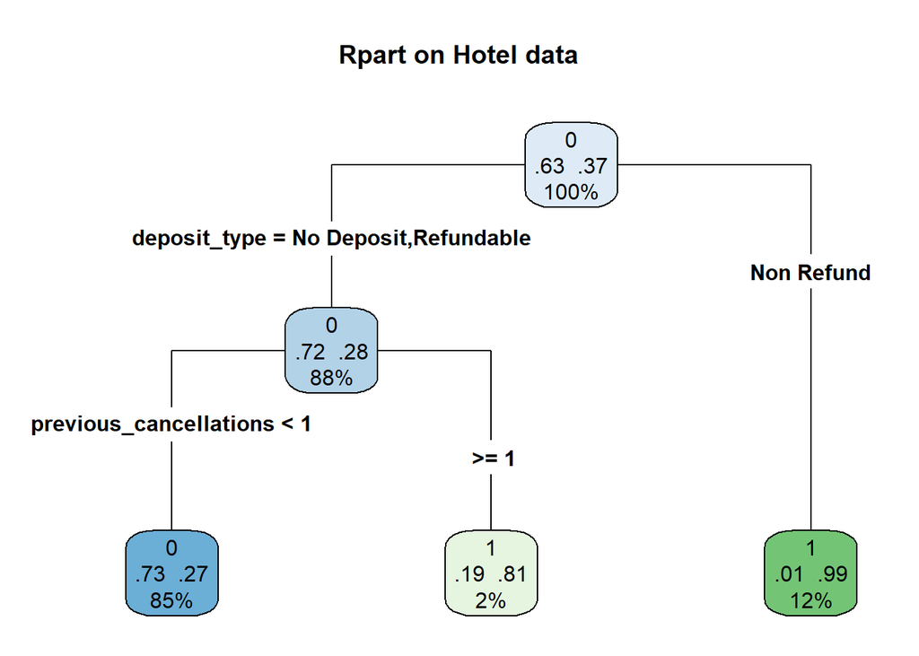

```r
library(rpart)
library(rpart.plot)
model <- rpart(is_canceled ~ deposit_type + previous_cancellations + arrival_date, method = "class", data = train)

rpart.plot(model, extra = 104, fallen.leaves = T, type = 4,
           main = "Rpart on Hotel data")
```

```r
# now we can run our model on the test data set
pred <- predict(model, test, type = "class")
# create a table of actual vs predicted classes
conf_matrix <- table(test$is_canceled, pred)

# print the confusion matrix
print(conf_matrix)
```

```
##    pred
##        0    1
##   0 7412   52
##   1 2776 1699
```

```r
accuracy <- sum(diag(conf_matrix)) / sum(conf_matrix)
cat("Accuracy:", round(accuracy, 4), "\n")
```

```
## Accuracy: 0.7631
```

```r
error_rate <- 1 - accuracy
cat("Error rate:", round(error_rate, 4), "\n")
```

```
## Error rate: 0.2369
```

```r
sensitivity <- conf_matrix[2, 2] / sum(conf_matrix[2, ])
cat("Sensitivity:", round(sensitivity, 4), "\n")
```

```
## Sensitivity: 0.3797
```

```r
specificity <- conf_matrix[1, 1] / sum(conf_matrix[1, ])
cat("Specificity:", round(specificity, 4), "\n")
```

```
## Specificity: 0.993
```

### Conclusions

After building the decision tree model using features such as deposit type, previous cancellations, and arrival date, I was able to apply it to the test dataset and evaluate its performance. The model achieved an accuracy of 76.31%, meaning that it correctly predicted whether a customer would cancel their booking about 76% of the time. While this accuracy is respectable, the sensitivity and specificity of the model provide a deeper insight into its performance.

To further evaluate the model, I used a confusion matrix, which is a useful tool for measuring classification performance. The confusion matrix compares the actual outcomes with the predicted outcomes, showing how well the model distinguishes between canceled and non-canceled bookings. In this case, the confusion matrix looked like this:

```
    pred
        0    1
   0 7412   52
   1 2776 1699
```

Here’s how to interpret each observation:

- **True Negatives (TN):** The model correctly predicted that 7,412 bookings would not be canceled (top-left value: `7412`).
- **False Positives (FP):** The model incorrectly predicted that 52 bookings would be canceled when they were not (top-right value: `52`).
- **False Negatives (FN):** The model incorrectly predicted that 2,776 bookings would not be canceled when they were actually canceled (bottom-left value: `2776`).
- **True Positives (TP):** The model correctly predicted that 1,699 bookings would be canceled (bottom-right value: `1699`).

The accuracy of 76.31% means that the model correctly predicted both canceled and non-canceled bookings. The **sensitivity** (also known as the true positive rate) of 37.97% indicates how well the model identifies actual cancellations, and the **specificity** of 99.3% shows how well it correctly predicts bookings that are not canceled. This high specificity means the model is excellent at identifying non-cancelled bookings, but the relatively low sensitivity suggests that the model struggles more with identifying actual cancellations.